Github webpage: https://trick491.github.io/

# **Exploring the Relationship Between Financial Statement Items and Stock Performance**

Patrick Johnson and Anh Pham

# Exploring How Financial Statement Items Relate to Stock Performance

## 1. Motivation: Why This Topic Matters

When people talk about why a stock goes up or down, they often focus on one number: **earnings per share (EPS)**.  
However, companies publish *hundreds* of financial numbers every year in their official filings with the U.S. Securities and Exchange Commission (SEC).

This project asks a simple but important question:

> **Besides earnings, do other financial numbers—such as assets, liabilities, or depreciation—help explain how a company’s stock price changes over time?**

Understanding this is valuable because stock prices are influenced by how strong or risky a company appears to investors. This tutorial aims to make the topic approachable for beginners, even if you have no background in accounting or finance.

This project aims to solve what financial professionals, phds, and professional hedge fund managers aim to solve. Is there some formula or model that can predict stock prices??? We want to explore just some of the complexities of this task from a data science perspective

## **Project Goals**

The goal of this project is to analyze and determine how different financial statement indexes correlate with stock price changes for companies in the S&P 500 over the past ten years. Instead of focusing on the most common measure, earnings per share (EPS), we want to see if factors like depreciation, assets, or liabilities also help explain stock performance. By finding these correlations, we hope to better understand how financial decisions and company internal set up are reflected in investor behavior and market value.

Furthermore, we want to predict market cap (total market value of all of the shares) which would get us to price per share, using most recent shares outstanding, a feature defined in the edgar documentation. This is a more robust way to make models that predict stock prices because market cap is scaled to the metrics in the dataset, unlike stock prices which don't mean much without knowing how many shares outstanding exist. Price per share share is stock split adjusted in the Yfinance documentation.

## **Project Dataset**

The datasets we are considering working with are the SEC EDGAR Financial Statement Metrics and Yahoo Finance Historical Stock Data. Together, these two datasets will allow us to examine how companies’ internal financial structures influence their external market performance over time. Our goal is to identify relationships between balance sheet and income statement items, especially those unrelated to earnings per share (EPS) (such as depreciation and total liabilities), and stock price trends for firms in the S&P 500 index.  
The SEC EDGAR dataset provides standardized financial statement information of publicly traded U.S. companies, including variables like total assets, total liabilities, depreciation, and operating income. The Yahoo Finance dataset contains corresponding market data such as daily closing prices and trading volumes. By organizing the stock data by year and linking it to the financial data from EDGAR using company tickers or IDs, we can create one dataset that shows both a company’s financial performance and its market value  
This integration will allow us to answer questions such as: How do changes in liabilities or depreciation expenses relate to changes in stock prices? Do firms with more asset growth correlate to higher long-term stock performance? Combining these two datasets bridges the gap between corporate accounting and investor behavior, providing a comprehensive foundation for analyzing how internal financial indicators translate into market outcomes.

## **Collaboration Plan**

Our collaboration plan is to divide tasks and work individually on google colab, while actively communicating via message. We will meet up in person once a week to update our progress, finalize our project vision, discuss the quality of our work, and resolve any issues. We have also set up a shared GitHub repository to coordinate our work and upload code. All code contributions are documented with clear comments and commit messages. One member will focus on data extraction and cleaning (ETL from EDGAR and Yahoo Finance). The other will handle data analysis and visualization, ensuring results are clearly communicated on our GitHub Pages website. We will focus on our task but also actively assist the other person when needed.

## **Further Datasets**

We wanted to include financial sector classifiers (i.e energy sector, technology sector, retail sector, etc.) and merge them on the dataset to see how correlations change across sectors. YFinance has sector descriptions we can utllize for this.

# **Glossary**

- **CIK** (Central Index Key): A unique 10-digit identifier assigned by the SEC to every entity that files with EDGAR, including public companies, mutual funds, and individuals. Used to look up filings in SEC APIs and EDGAR.
- **start**: The beginning date of the reporting period for the reported XBRL fact. Used for facts that cover a period (e.g., revenue for a quarter or year). Example: "start": "2024-01-01"
- **end**: The ending date of the reporting period for the fact. This, combined with start, defines the timeframe for period-based financial metrics.Example: "end": "2024-09-30"
- **val**: The numeric value of the XBRL-reported fact (e.g., revenue, assets, operating income). Usually appears as a raw number without formatting. Example: "val": 73582000000 (which is 73.582B)
- **accn** (Accession Number): A unique EDGAR-generated ID for the specific filing containing this fact. You can use it to locate the filing’s directory and document list. Example: "accn": "0001652044-24-000118"
- **fy** (Fiscal Year): The fiscal year associated with the filing (not necessarily the calendar year). Companies with non-December year-ends may have FY differing from calendar year. Example: "fy": 2024
- **fp** (Fiscal Period): The fiscal period represented by the filing. Common values include: Q1 = First fiscal quarter
- **filed**: The date the filing was submitted to the SEC EDGAR system.
- **frame**: A special time-period code used by XBRL for instant or duration frames.

Before we begin working with the data, we will explain the financial terms and how these elements are used in later codes. Our project focuses on analyzing companies in the S&P 500, a list of the 500 leading stock exchange companies in the U.S.

What is a “Ticker”? A ticker, also called a stock symbol, is a short and unique abbreviation used to identify a publicly traded company in the stock market. A company is assigned a ticker when it goes public and trades stocks the first time. For example: Apple’s ticker is AAPL, Google’s is GOOGL, and Walmart is WMT. Tickers exist to prevent name confusion as many companies share similar names/terms.

Lets mount our drive:

```python
from google.colab import drive
drive.mount('/content/drive')
```

Pull in all tickers to feed into CIK - Ticker conversion

Later in this project, we will collect official financial information for each company from the U.S. Securities and Exchange Commission (SEC). The SEC assigns each company a special ID number called a CIK (Central Index Key). However: The SEC does NOT recognize stock tickers (only CIK numbers). To access financial filings, we must convert the company’s ticker into a CIK number. Then use the CIK to request the financial data.

In this step, we will download a table from *stockanalysis.com* that lists all companies in the S&P 500.

We then read that table into Python and pull out the column that contains the company ticker symbols (for example: AAPL, MSFT, GOOG). These tickers will be used later to help us match each company to its CIK code in the SEC database.

### **Step 1: Fetch S&P 500 Company List**

We scrape the current list of S&P 500 companies from stockanalysis.com. This gives us the ticker symbols (e.g., AAPL, MSFT) for all 500 companies in the index, which we will use to collect financial data.

```python
import pandas as pd
import requests
from io import StringIO

# Step 1: Define S&P 500 tickers list
response = requests.get("https://stockanalysis.com/list/sp-500-stocks/")
html_content = response.text

# Parse tables from the HTML
tables = pd.read_html(StringIO(html_content))

# The S&P 500 table is typically the first table
sp500_df = tables[0]

display(sp500_df.head())
print(f"\nTotal stocks: {len(sp500_df)}")

sp500_tickers = sp500_df['Symbol']

sp500_tickers.head()
```

|  | No. | Symbol | Company Name | Market Cap | Stock Price | % Change | Revenue |
| --- | --- | --- | --- | --- | --- | --- | --- |
| 0 | 1 | NVDA | NVIDIA Corporation | 4.40T | 180.93 | -1.55% | 187.14B |
| 1 | 2 | AAPL | Apple Inc. | 4.11T | 278.03 | -0.27% | 416.16B |
| 2 | 3 | GOOG | Alphabet Inc. | 3.78T | 313.70 | -2.27% | 385.48B |
| 3 | 4 | GOOGL | Alphabet, Inc. | 3.77T | 312.43 | -2.43% | 385.48B |
| 4 | 5 | MSFT | Microsoft Corporation | 3.59T | 483.47 | 1.03% | 293.81B |

```
Total stocks: 502
```

|  | Symbol |
| --- | --- |
| 0 | NVDA |
| 1 | AAPL |
| 2 | GOOG |
| 3 | GOOGL |
| 4 | MSFT |

**dtype:** object

### **Step 2: Map Tickers to SEC CIK Numbers**

The SEC identifies companies by CIK (Central Index Key) numbers, not ticker symbols. This cell downloads the official SEC ticker-to-CIK mapping and matches each S&P 500 ticker to its corresponding 10-digit CIK number, which is required to access SEC EDGAR filings.

```python
import requests
import pandas as pd

# The SEC requires us to include a user-agent when making requests
headers = {
    'User-Agent': 'Your Company Name pjohnson3@tulane.edu',
    'Accept-Encoding': 'gzip, deflate'
}

# Download the SEC file that lists tickers and their CIK numbers
CIK = requests.get('https://www.sec.gov/include/ticker.txt', headers=headers)

# Turn the text file into a dictionary: {Symbol : CIK}
ticker_map = dict(line.split('\t') for line in CIK.text.upper().strip().split('\n') if line)

# Convert the dictionary into a DataFrame for easier use
ticker_map = pd.DataFrame(list(ticker_map.items()), columns=['Symbol', 'CIK'])

# Make sure all CIKs are 10 digits long (add leading zeros if needed)
ticker_map['CIK'] = ticker_map['CIK'].astype(str).str.zfill(10)

# Remove duplicate CIK numbers to keep the table clean
ticker_map = ticker_map.drop_duplicates(subset='CIK', keep='first')

# Match S&P 500 tickers with their CIK numbers
sp500_cik = pd.merge(sp500_tickers, ticker_map, on='Symbol', how='left')

# Print preview to ensure everthing works
print(sp500_cik.head())
print(f"Total symbols: {sp500_cik['Symbol'].count()}")
print(f"Unique CIKs: {sp500_cik['CIK'].nunique()}")
print(f"\nSample CIKs (should be 10 digits):")
print(sp500_cik[['Symbol', 'CIK']].head(10))
```

```
  Symbol         CIK
0   NVDA  0001045810
1   AAPL  0000320193
2   GOOG         NaN
3  GOOGL  0001652044
4   MSFT  0000789019
Total symbols: 502
Unique CIKs: 479

Sample CIKs (should be 10 digits):
  Symbol         CIK
0   NVDA  0001045810
1   AAPL  0000320193
2   GOOG         NaN
3  GOOGL  0001652044
4   MSFT  0000789019
5   AMZN  0001018724
6   AVGO  0001730168
7   META  0001326801
8   TSLA  0001318605
9  BRK.B         NaN
```

### **Step 3: Define Target Companies and API Credentials**

We define the subset of companies to analyze and set up the required SEC API headers - 50 because it's a good amount of data but small enough to work with. The SEC requires a User-Agent header with contact information for all API requests.

```python
# The SEC requires us to include a User-Agent so they know who is making the request
headers = {
    'User-Agent': 'Patrick Johnson pjohnson3@tulane.edu'  # Replace with your info
}

# CIK list - properly formatted with leading zeros (10 digits)
CIK_list = sp500_cik['CIK'].to_list()[:50]  # Google (Alphabet) and Apple
#CIK_list = ['0001045810','0000059478', '0000320193', '0001652044']

# Create DataFrame to store all SEC financial data
all_edgar_df = pd.DataFrame()
```

### **Step 4: Extract Financial Data from SEC EDGAR**

This is the core ETL (Extract, Transform, Load) step. For each company, we:

1. Query the SEC EDGAR API for all reported financial facts (us-gaap and dei namespaces)
2. Extract shares outstanding data separately for market cap calculations
3. Parse XBRL-formatted financial statements into a structured DataFrame
4. Track the most recent shares outstanding for each company

**Note:** Companies without shares outstanding data are dropped since we need this for market cap calculations.

```python
import pandas as pd
import requests

# Assuming CIK_list and sp500_cik are already defined
namespaces = ['us-gaap', 'dei']
all_edgar_df = pd.DataFrame()  # To store US-GAAP metrics
all_shares_df = pd.DataFrame() # To store Shares Outstanding
SHARES_FACT_NAME = 'EntityCommonStockSharesOutstanding'

for cik in CIK_list:
    edgar_api = f'https://data.sec.gov/api/xbrl/companyfacts/CIK{str(cik).zfill(10)}.json'
    try:
        edgar_response = requests.get(edgar_api, headers={'User-Agent': 'Example App YourName@example.com'})
        edgar_response.raise_for_status()
        data = edgar_response.json()
    except requests.exceptions.RequestException as e:
        print(f"Error fetching CIK {cik}: {e}")
        continue

    financial_data = []
    shares_data = []

    try:
        ticker = sp500_cik.loc[sp500_cik['CIK'] == str(cik).zfill(10), 'Symbol'].iloc[0]
    except IndexError:
        print(f"Warning: Ticker not found for CIK {cik}. Skipping.")
        continue

    for namespace in namespaces:
        if namespace in data.get('facts', {}):
            for fact_name, fact_details in data['facts'][namespace].items():
                if 'units' in fact_details:
                    for unit_type, records in fact_details['units'].items():
                        for record in records:
                            record_dict = {
                                'fact_name': fact_name,
                                'label': fact_details.get('label', ''),
                                'description': fact_details.get('description', ''),
                                'unit': unit_type,
                                'value': record.get('val'),
                                'start_date': record.get('start'),
                                'end_date': record.get('end'),
                                'filed_date': record.get('filed'),
                                'form': record.get('form'),
                                'frame': record.get('frame', ''),
                                'fiscal_year': record.get('fy'),
                                'fiscal_period': record.get('fp'),
                                'accn': record.get('accn'),
                                'company_cik': data.get('cik'),
                                'company_name': data.get('entityName'),
                                'Ticker': ticker
                            }
                            if fact_name == SHARES_FACT_NAME:
                                shares_data.append(record_dict)
                            else:
                                financial_data.append(record_dict)

    # Conditional Logic to Drop Company (from previous fix)
    if not shares_data:
        print(f"*** WARNING: Dropping company {ticker} (CIK {cik}) because no '{SHARES_FACT_NAME}' data was found. ***")
        continue

    all_edgar_df = pd.concat([all_edgar_df, pd.DataFrame(financial_data)], ignore_index=True)
    all_shares_df = pd.concat([all_shares_df, pd.DataFrame(shares_data)], ignore_index=True)
    print(f"Loaded {len(financial_data)} metric records and {len(shares_data)} shares records for {ticker}")

# --- CLEAN SHARES DATA AND GET CURRENT SHARES ---

# Rename value column for clarity
all_shares_df.rename(columns={'value': 'Shares_Outstanding'}, inplace=True)

# Convert dates
all_shares_df['end_date'] = pd.to_datetime(all_shares_df['end_date'], errors='coerce')
all_shares_df['filed_date'] = pd.to_datetime(all_shares_df['filed_date'], errors='coerce')

# Drop duplicates: keep the last record per Ticker + filed_date
all_shares_df = all_shares_df.sort_values(['Ticker', 'filed_date', 'end_date'])
all_shares_df = all_shares_df.drop_duplicates(subset=['Ticker', 'filed_date'], keep='last').reset_index(drop=True)

print("\n--- Cleaned Shares Outstanding Sample ---")
print(all_shares_df[['Ticker', 'end_date', 'filed_date', 'Shares_Outstanding']].head())

# GET CURRENT SHARES OUTSTANDING FOR EACH TICKER
current_shares_dict = {}
for ticker in all_shares_df['Ticker'].unique():
    ticker_shares = all_shares_df[all_shares_df['Ticker'] == ticker].sort_values('end_date', ascending=False)
    if len(ticker_shares) > 0:
        current_shares_dict[ticker] = ticker_shares.iloc[0]['Shares_Outstanding']

print("\n--- Current Shares Outstanding by Ticker ---")
for ticker, shares in current_shares_dict.items():
    print(f"{ticker}: {shares/1e9:.2f}B shares")

# ADD CURRENT SHARES TO ALL_EDGAR_DF
all_edgar_df['Current_Shares_Outstanding'] = all_edgar_df['Ticker'].map(current_shares_dict)

print(f"\n✓ Added Current_Shares_Outstanding column to all_edgar_df")
print(f"Sample:")
print(all_edgar_df[['Ticker', 'fact_name', 'value', 'Current_Shares_Outstanding']].head())
```

```
Loaded 25955 metric records and 66 shares records for NVDA
Loaded 24309 metric records and 67 shares records for AAPL
Error fetching CIK nan: 404 Client Error: Not Found for url: https://data.sec.gov/api/xbrl/companyfacts/CIK0000000nan.json
*** WARNING: Dropping company GOOGL (CIK 0001652044) because no 'EntityCommonStockSharesOutstanding' data was found. ***
Loaded 31018 metric records and 65 shares records for MSFT
Loaded 28106 metric records and 66 shares records for AMZN
Loaded 13850 metric records and 30 shares records for AVGO
*** WARNING: Dropping company META (CIK 0001326801) because no 'EntityCommonStockSharesOutstanding' data was found. ***
Loaded 22779 metric records and 63 shares records for TSLA
Error fetching CIK nan: 404 Client Error: Not Found for url: https://data.sec.gov/api/xbrl/companyfacts/CIK0000000nan.json
Loaded 23953 metric records and 67 shares records for WMT
Loaded 22471 metric records and 67 shares records for LLY
Loaded 47494 metric records and 70 shares records for JPM
Loaded 22663 metric records and 2 shares records for V
Loaded 24632 metric records and 65 shares records for ORCL
Loaded 26131 metric records and 66 shares records for JNJ
Loaded 26238 metric records and 4 shares records for MA
Loaded 19828 metric records and 67 shares records for XOM
*** WARNING: Dropping company PLTR (CIK 0001321655) because no 'EntityCommonStockSharesOutstanding' data was found. ***
Loaded 22580 metric records and 68 shares records for NFLX
Loaded 43144 metric records and 67 shares records for BAC
Loaded 19322 metric records and 51 shares records for ABBV
Loaded 23559 metric records and 64 shares records for COST
Loaded 22480 metric records and 62 shares records for AMD
Loaded 20291 metric records and 66 shares records for HD
Loaded 24825 metric records and 68 shares records for PG
Loaded 39530 metric records and 65 shares records for CSCO
Loaded 27748 metric records and 66 shares records for UNH
Loaded 38774 metric records and 72 shares records for GE
Loaded 30480 metric records and 68 shares records for CVX
Loaded 31949 metric records and 69 shares records for KO
Loaded 37728 metric records and 67 shares records for CAT
Loaded 49709 metric records and 67 shares records for WFC
Loaded 35838 metric records and 65 shares records for IBM
Loaded 26088 metric records and 61 shares records for MU
Loaded 43572 metric records and 66 shares records for MS
Loaded 36079 metric records and 68 shares records for GS
Loaded 30409 metric records and 66 shares records for AXP
Loaded 29944 metric records and 67 shares records for CRM
Loaded 27925 metric records and 67 shares records for MRK
```

[output cut: 65 more lines]

```
✓ Added Current_Shares_Outstanding column to all_edgar_df
Sample:
  Ticker                                          fact_name       value  \
0   NVDA        AcceleratedShareRepurchaseProgramAdjustment  9000000.00
1   NVDA        AcceleratedShareRepurchaseProgramAdjustment  9000000.00
2   NVDA  AcceleratedShareRepurchasesFinalPricePaidPerShare       21.63
3   NVDA  AcceleratedShareRepurchasesFinalPricePaidPerShare       42.06
4   NVDA  AcceleratedShareRepurchasesFinalPricePaidPerShare       42.06

   Current_Shares_Outstanding
0                2.430000e+10
1                2.430000e+10
2                2.430000e+10
3                2.430000e+10
4                2.430000e+10
```

### **Step 5: Load Historical Stock Price Data**

We load pre-collected Yahoo Finance stock price data from our GitHub repository. This data contains daily closing prices and trading volumes for our target companies, which will be merged with the financial statement data to create our target variable (stock price).

```python
# Download daily stock prices (Yahoo Finance) from GitHub
yahoo_api = 'https://api.github.com/repos/trick491/Data-Science-Final-Project/contents/data/yahoo'
yahoo_response = requests.get(yahoo_api)
yahoo_df = pd.DataFrame()

# Make sure the folder request succeeded
if yahoo_response.status_code == 200:
    yahoo_files = yahoo_response.json()

    # Loop through files and load any that end in .csv
    for file in yahoo_files:
        if file['name'].endswith('.csv'):
            file_url = file['download_url']
            # Read the CSV into a temporary DataFrame
            df_temp = pd.read_csv(file_url)
            # Add it to the combined Yahoo data
            yahoo_df = pd.concat([yahoo_df, df_temp], ignore_index=True)
            print(f"Loaded Yahoo file: {file['name']}")

print(f"\nTotal EDGAR DataFrame shape: {all_edgar_df.shape}")
print(f"Yahoo DataFrame shape: {yahoo_df.shape}")
```

```
Loaded Yahoo file: yahoo_1.csv
Loaded Yahoo file: yahoo_10.csv
Loaded Yahoo file: yahoo_11.csv
Loaded Yahoo file: yahoo_12.csv
Loaded Yahoo file: yahoo_13.csv
Loaded Yahoo file: yahoo_14.csv
Loaded Yahoo file: yahoo_15.csv
Loaded Yahoo file: yahoo_16.csv
Loaded Yahoo file: yahoo_17.csv
Loaded Yahoo file: yahoo_18.csv
Loaded Yahoo file: yahoo_19.csv
Loaded Yahoo file: yahoo_2.csv
Loaded Yahoo file: yahoo_20.csv
Loaded Yahoo file: yahoo_21.csv
Loaded Yahoo file: yahoo_22.csv
Loaded Yahoo file: yahoo_23.csv
Loaded Yahoo file: yahoo_24.csv
Loaded Yahoo file: yahoo_25.csv
Loaded Yahoo file: yahoo_26.csv
Loaded Yahoo file: yahoo_27.csv
Loaded Yahoo file: yahoo_28.csv
Loaded Yahoo file: yahoo_29.csv
Loaded Yahoo file: yahoo_3.csv
Loaded Yahoo file: yahoo_30.csv
Loaded Yahoo file: yahoo_31.csv
Loaded Yahoo file: yahoo_32.csv
Loaded Yahoo file: yahoo_33.csv
Loaded Yahoo file: yahoo_34.csv
Loaded Yahoo file: yahoo_35.csv
Loaded Yahoo file: yahoo_36.csv
Loaded Yahoo file: yahoo_37.csv
Loaded Yahoo file: yahoo_38.csv
Loaded Yahoo file: yahoo_4.csv
Loaded Yahoo file: yahoo_5.csv
Loaded Yahoo file: yahoo_6.csv
Loaded Yahoo file: yahoo_7.csv
Loaded Yahoo file: yahoo_8.csv
Loaded Yahoo file: yahoo_9.csv

Total EDGAR DataFrame shape: (1271540, 17)
Yahoo DataFrame shape: (4318433, 9)
```

### **Step 6: Data Quality Inspection**

Before proceeding with analysis, we inspect both datasets to verify:

- Data types are correct (dates as datetime, values as numeric)
- Column names and structure match expectations
- Sample data looks reasonable

This is a critical sanity check before merging datasets.

```python
# Display sample data and data types
print("\nEDGAR US-GAAP Data Sample:")
display(all_edgar_df.loc[all_edgar_df['Ticker'] == 'GOOGL'].head(1))

# Print data type
print("\n EDGAR Data Types:")
display(all_edgar_df.dtypes.to_frame('dtype'))
```

```
EDGAR US-GAAP Data Sample:
```

|  | fact_name | label | description | unit | value | start_date | end_date | filed_date | form | frame | fiscal_year | fiscal_period | accn | company_cik | company_name | Ticker | Current_Shares_Outstanding |
| --- | --- | --- | --- | --- | --- | --- | --- | --- | --- | --- | --- | --- | --- | --- | --- | --- | --- |

```
 EDGAR Data Types:
```

|  | dtype |
| --- | --- |
| fact_name | object |
| label | object |
| description | object |
| unit | object |
| value | float64 |
| start_date | object |
| end_date | object |
| filed_date | object |
| form | object |
| frame | object |
| fiscal_year | float64 |
| fiscal_period | object |
| accn | object |
| company_cik | int64 |
| company_name | object |
| Ticker | object |
| Current_Shares_Outstanding | float64 |

**Cleaning the EDGAR Data**

- `fact_name`: the name of the financial metric
- `value`: the reported value
- `start_date`, `end_date`, `filed_date`: the reporting dates
- `form`: the form type (10-K, 10-Q, etc.)
- `fiscal_year`, `fiscal_period`: the fiscal year/period
- `Ticker`: the company ticker

Step 8: Prepare Shares Outstanding Data We clean and deduplicate the shares outstanding data to create a lookup table. For each company at each reporting date, we will have the number of shares outstanding, which is essential for converting between stock price and market capitalization.

```python
shares_for_merge = all_shares_df[['Ticker', 'end_date', 'Shares_Outstanding']].copy()
shares_for_merge['end_date'] = pd.to_datetime(shares_for_merge['end_date'], errors='coerce')
shares_for_merge = shares_for_merge.dropna(subset=['end_date'])
shares_for_merge = shares_for_merge.drop_duplicates(subset=['Ticker', 'end_date'])
shares_for_merge = shares_for_merge.sort_values(['Ticker', 'end_date']).reset_index(drop=True)

print(f"Shares data prepared: {len(shares_for_merge)} rows")
print(f"Tickers with shares data: {shares_for_merge['Ticker'].nunique()}")
```

```
Shares data prepared: 2694 rows
Tickers with shares data: 44
```

### **Step 9: Define Quarterly Normalization Function**

SEC filings report financial metrics in different time periods:

- **Quarterly (Q1-Q4):** Direct quarterly values
- **Year-to-Date (YTD):** Cumulative values (e.g., Q3 YTD = Q1+Q2+Q3)
- **Full Year (FY):** Annual totals

This function normalizes all data to **quarterly values** by:

1. Identifying the reporting period type based on date ranges
2. Calculating individual quarter values from YTD figures (e.g., Q2 = Q2_YTD - Q1)
3. Extracting Q4 from FY values (Q4 = FY - Q3_YTD)

This ensures all metrics are comparable across the same time granularity.

```python
def q_normalize(variable):
    variable = variable.copy()

    # Check if start_date column exists
    if 'start_date' not in variable.columns:
        return variable

    # FIX: Convert dates to datetime at the very beginning
    variable['start_date'] = pd.to_datetime(variable['start_date'], errors='coerce')
    variable['end_date'] = pd.to_datetime(variable['end_date'], errors='coerce')

    # Remove rows with invalid dates
    variable = variable.dropna(subset=['start_date', 'end_date'])

    # Remove comparative data by keeping only the earliest filing for each end_date + fiscal_period
    if 'filed' in variable.columns:
        variable['filed'] = pd.to_datetime(variable['filed'], errors='coerce')
        variable = variable.sort_values('filed')
        variable = variable.drop_duplicates(subset=['end_date', 'fiscal_period'], keep='first')

    variable_narrowed = pd.DataFrame(columns=variable.columns)

    for _, row in variable.iterrows():
        start = row['start_date']  # Already datetime
        end = row['end_date']      # Already datetime

        # Compute days difference
        days_diff = (end - start).days

        if days_diff < 100:
            # Keep actual quarterly data (days < 100)
            variable_narrowed = pd.concat([variable_narrowed, row.to_frame().T], ignore_index=True)
        else:
            # Handle FY -> Q4 conversion (FY - Q3 YTD)
            if row['fiscal_period'] == 'FY':
                q4 = row.copy()
                q4['fiscal_period'] = 'Q4'
                q4['start_date'] = end - pd.DateOffset(months=3)

                # Get Q3 YTD matching rows - same end_date year
                q3_ytd_match = variable.loc[
                    (variable['end_date'].dt.year == end.year) &
                    (variable['fiscal_period'] == 'Q3') &
                    ((variable['end_date'] - variable['start_date']).dt.days > 100)
                ]

                # Subtract Q3 YTD value if it exists
                if not q3_ytd_match.empty:
                    q4['value'] = float(q4['value']) - float(q3_ytd_match.iloc[0]['value'])
                    variable_narrowed = pd.concat([variable_narrowed, q4.to_frame().T], ignore_index=True)

            # Handle Q2 YTD -> extract Q1 and Q2
            elif row['fiscal_period'] == 'Q2':
                # METHOD 1: Try to find actual Q2 (days < 100) - same end_date year
                q2_actual_match = variable.loc[
                    (variable['end_date'].dt.year == end.year) &
                    (variable['fiscal_period'] == 'Q2') &
                    ((variable['end_date'] - variable['start_date']).dt.days < 100)
                ]

                if not q2_actual_match.empty:
                    # We have actual Q2, so calculate Q1 = Q2_YTD - Q2_actual
                    q1 = row.copy()
                    q1['fiscal_period'] = 'Q1'
                    q1['end_date'] = start
                    q1['start_date'] = start - pd.DateOffset(months=3)
                    q1['value'] = float(row['value']) - float(q2_actual_match.iloc[0]['value'])
                    variable_narrowed = pd.concat([variable_narrowed, q1.to_frame().T], ignore_index=True)
                else:
                    # METHOD 2: No actual Q2 found, try Q1 YTD method
                    q1_ytd_match = variable.loc[
                        (variable['end_date'].dt.year == end.year) &
                        (variable['fiscal_period'] == 'Q1') &
                        ((variable['end_date'] - variable['start_date']).dt.days > 100)
                    ]

                    if not q1_ytd_match.empty:
                        # Calculate Q2 = Q2_YTD - Q1_YTD
                        q2 = row.copy()
                        q1_ytd_end = q1_ytd_match.iloc[0]['end_date']
                        q2['start_date'] = q1_ytd_end
                        q2['value'] = float(row['value']) - float(q1_ytd_match.iloc[0]['value'])
                        variable_narrowed = pd.concat([variable_narrowed, q2.to_frame().T], ignore_index=True)

                        # Also extract Q1 from Q1_YTD if it doesn't exist as actual
                        q1_actual_match = variable.loc[
                            (variable['end_date'].dt.year == end.year) &
                            (variable['fiscal_period'] == 'Q1') &
                            ((variable['end_date'] - variable['start_date']).dt.days < 100)
                        ]

                        if q1_actual_match.empty:
                            q1 = q1_ytd_match.iloc[0].copy()
                            variable_narrowed = pd.concat([variable_narrowed, q1.to_frame().T], ignore_index=True)

            # Handle Q3 YTD -> extract Q3
            elif row['fiscal_period'] == 'Q3':
                # METHOD 1: Try to find actual Q3 (days < 100) - same end_date year
                q3_actual_match = variable.loc[
                    (variable['end_date'].dt.year == end.year) &
                    (variable['fiscal_period'] == 'Q3') &
                    ((variable['end_date'] - variable['start_date']).dt.days < 100)
                ]

                if q3_actual_match.empty:
                    # METHOD 2: Calculate Q3 = Q3_YTD - Q2_YTD - same end_date year
                    q2_ytd_match = variable.loc[
                        (variable['end_date'].dt.year == end.year) &
                        (variable['fiscal_period'] == 'Q2') &
                        ((variable['end_date'] - variable['start_date']).dt.days > 100)
                    ]

                    if not q2_ytd_match.empty:
                        q3 = row.copy()
                        q2_ytd_end = q2_ytd_match.iloc[0]['end_date']
                        q3['start_date'] = q2_ytd_end
                        q3['value'] = float(row['value']) - float(q2_ytd_match.iloc[0]['value'])
                        variable_narrowed = pd.concat([variable_narrowed, q3.to_frame().T], ignore_index=True)

    # Sort by end_date FIRST before deduplication
    variable_narrowed = variable_narrowed.sort_values('end_date')

    # Deduplicate by keeping one row per end_date
    variable_narrowed = variable_narrowed.drop_duplicates(subset=['end_date'], keep='first')

    return variable_narrowed
```

### **Step 10: Apply Quarterly Normalization**

We apply the normalization function to every financial metric for every company. This loops through each ticker and each unique financial fact, converting all values to quarterly periods.

```python
normalized = pd.DataFrame(columns=all_edgar_df.columns)
unique_tickers = all_edgar_df['Ticker'].unique().tolist()

print(f"Processing {len(unique_tickers)} tickers...")

for count, ticker in enumerate(unique_tickers, 1):
    print(f"  {ticker} ({count}/{len(unique_tickers)})")

    ticker_data = all_edgar_df[all_edgar_df['Ticker'] == ticker].copy()

    for fact_name in ticker_data['fact_name'].unique():
        fact_data = ticker_data[ticker_data['fact_name'] == fact_name]

        try:
            normalized_fact = q_normalize(fact_data)
            normalized = pd.concat([normalized, normalized_fact], ignore_index=True)
        except (OverflowError, ValueError, TypeError) as e:
            print(f"    Warning: Skipping {fact_name} - {str(e)[:50]}")
            continue

print(f"\nNormalized data: {len(normalized)} rows")
print(f"Unique facts: {normalized['fact_name'].nunique()}")
```

```
Processing 44 tickers...
  NVDA (1/44)
  AAPL (2/44)
  MSFT (3/44)
  AMZN (4/44)
  AVGO (5/44)
  TSLA (6/44)
  WMT (7/44)
  LLY (8/44)
  JPM (9/44)
  V (10/44)
  ORCL (11/44)
    Warning: Skipping RestructuringAndRelatedCostExpectedCost - Overflow in int64 addition
  JNJ (12/44)
  MA (13/44)
  XOM (14/44)
  NFLX (15/44)
  BAC (16/44)
  ABBV (17/44)
  COST (18/44)
  AMD (19/44)
  HD (20/44)
  PG (21/44)
  CSCO (22/44)
  UNH (23/44)
  GE (24/44)
  CVX (25/44)
  KO (26/44)
  CAT (27/44)
  WFC (28/44)
  IBM (29/44)
  MU (30/44)
  MS (31/44)
  GS (32/44)
  AXP (33/44)
  CRM (34/44)
  MRK (35/44)
  RTX (36/44)
  PM (37/44)
  MCD (38/44)
  TMUS (39/44)
  TMO (40/44)
  AMAT (41/44)
  ABT (42/44)
  LRCX (43/44)
  PEP (44/44)

Normalized data: 272187 rows
Unique facts: 1933
```

### **Step 11: Group Features into Quarterly Windows**

Financial filings often contain multiple facts reported on the same date. We:

1. Create quarterly period identifiers (e.g., 2023Q1)
2. Group all financial metrics that belong to the same quarter
3. Identify the latest filing date per quarter to ensure we are using the most current data

```python
# Ensure dates are datetime type
normalized['end_date'] = pd.to_datetime(normalized['end_date'], errors='coerce')
normalized['filed_date'] = pd.to_datetime(normalized['filed_date'], errors='coerce')
normalized = normalized.dropna(subset=['end_date', 'filed_date'])

# Create quarterly periods to group filings within 90 days
normalized['quarter'] = normalized['end_date'].dt.to_period('Q')

print(f"Unique (Ticker, Quarter) pairs: {normalized.groupby(['Ticker', 'quarter']).ngroups}")

# For each quarter, find the LATEST filed_date (most recent filing)
latest_filing_per_quarter = normalized.groupby(['Ticker', 'quarter'])['filed_date'].max().reset_index()
latest_filing_per_quarter.columns = ['Ticker', 'quarter', 'best_filed_date']

print(f"Latest filing dates identified for {len(latest_filing_per_quarter)} quarters")

# Merge back to associate each row with the best filing date for that quarter
normalized = normalized.merge(
    latest_filing_per_quarter,
    on=['Ticker', 'quarter'],
    how='left'
)
```

```
Unique (Ticker, Quarter) pairs: 3046
Latest filing dates identified for 3046 quarters
```

CALCULATING PRICES FOR EACH QUARTER (Avg. ensueing 5 day price after filed_date)

This creates the first part of the target variable we need to look at the PRICE in price x shares = market cap

```python
DAYS_AFTER = 5

# Prepare price data
yahoo_df['Date'] = pd.to_datetime(yahoo_df['Date'], errors='coerce', utc=True)
yahoo_df = yahoo_df.dropna(subset=['Date'])
yahoo_df['Date'] = yahoo_df['Date'].dt.tz_localize(None)
yahoo_df = yahoo_df.sort_values(['Ticker', 'Date']).reset_index(drop=True)

# Get unique quarters
unique_quarters = normalized[['Ticker', 'quarter', 'best_filed_date']].drop_duplicates()

print(f"Processing {len(unique_quarters)} unique quarters...")

results = []

for idx, row in unique_quarters.iterrows():
    ticker = row['Ticker']
    filing_date = row['best_filed_date']

    ticker_prices = yahoo_df[
        (yahoo_df['Ticker'] == ticker) &
        (yahoo_df['Date'] > filing_date)
    ].copy()

    if len(ticker_prices) >= DAYS_AFTER:
        avg_price = ticker_prices.iloc[0:DAYS_AFTER]['Close'].mean()

        results.append({
            'Ticker': ticker,
            'quarter': row['quarter'],
            'best_filed_date': filing_date,
            f'Avg_Price_{DAYS_AFTER}_Days': avg_price
        })

quarter_price_data = pd.DataFrame(results)

print(f"\nCalculated prices for {len(quarter_price_data)} quarters")
print(f"Average price: ${quarter_price_data[f'Avg_Price_{DAYS_AFTER}_Days'].mean():.2f}")
```

```
Processing 3046 unique quarters...

Calculated prices for 2943 quarters
Average price: $115.11
```

Now we integrate the financial data with the target stock price data and calculate the final dependent variable for your models: Market Capitalization. We merge the normalized financial metrics with the average future stock price based on the Ticker and quarter

### **Step 13: Merge Financial Data with Stock Prices**

We combine the normalized financial metrics with the target stock prices by matching on Ticker and quarter. This creates our analysis-ready dataset where each row represents one company-quarter with all associated financial metrics and the future stock price.

```python
avg_price_col = f'Avg_Price_{DAYS_AFTER}_Days'

# Merge prices
merged_data = normalized.merge(
    quarter_price_data[['Ticker', 'quarter', avg_price_col]],
    on=['Ticker', 'quarter'],
    how='inner'
)

print(f"After merging prices: {len(merged_data)} rows")

# Calculate Market Cap = Price × Current Shares (split-adjusted)
merged_data[avg_price_col] = pd.to_numeric(merged_data[avg_price_col], errors='coerce')
merged_data['Current_Shares_Outstanding'] = pd.to_numeric(merged_data['Current_Shares_Outstanding'], errors='coerce')
merged_data['Market_Cap'] = merged_data[avg_price_col] * merged_data['Current_Shares_Outstanding']

# Remove rows with missing market cap
merged_data = merged_data.dropna(subset=['Market_Cap', 'Current_Shares_Outstanding'])

print(f"After calculating Market Cap: {len(merged_data)} rows")
print(f"Average Market Cap: ${merged_data['Market_Cap'].mean()/1e9:.2f}B")
print(f"Max Market Cap: ${merged_data['Market_Cap'].max()/1e9:.2f}B")
print(f"Min Market Cap: ${merged_data['Market_Cap'].min()/1e9:.2f}B")
```

```
After merging prices: 263230 rows
After calculating Market Cap: 263230 rows
Average Market Cap: $224.19B
Max Market Cap: $4263.68B
Min Market Cap: $2.26B
```

PIVOT TO WIDE FORMAT (ONE ROW PER QUARTER). Now we convert the financial data from a "long" format (where each financial fact is a separate row) into a "wide" format (where each financial fact becomes a separate column), making the data ready for operations like finding correlations and our model. We also handles data quality issues related to duplicate filings and data overlaps.

### **Step 14: Pivot Data to Wide Format**

Transform from long format (one row per metric) to wide format (one row per company-quarter with metrics as columns). This creates a feature matrix where:

- Each row = one company at one quarter
- Each column = one financial metric (e.g., Revenue, Assets, Liabilities)

This is the format required for machine learning models.

```python
# Check for duplicates before pivot
print(f"Before deduplication: {len(merged_data)} rows")
print(f"Unique (Ticker, Quarter): {merged_data.groupby(['Ticker', 'quarter']).ngroups}")

# Remove duplicates at the fact level - keep first occurrence
merged_data = merged_data.sort_values(['Ticker', 'quarter', 'best_filed_date'], ascending=[True, True, False])
merged_data = merged_data.drop_duplicates(subset=['Ticker', 'quarter', 'fact_name'], keep='first')

print(f"After fact-level dedup: {len(merged_data)} rows")

# CRITICAL FIX: Keep only data from quarters that match their best_filed_date
merged_data_filtered = merged_data[merged_data['filed_date'] == merged_data['best_filed_date']].copy()

print(f"After filtering to match filing dates: {len(merged_data_filtered)} rows")

# Pivot: one row per (Ticker, Quarter)
metrics_wide = merged_data_filtered.pivot_table(
    index=['Ticker', 'quarter', 'best_filed_date', 'Current_Shares_Outstanding', avg_price_col, 'Market_Cap'],
    columns='fact_name',
    values='value',
    aggfunc='first'
).reset_index()

print(f"Pivoted data shape: {metrics_wide.shape}")
print(f"  Rows (quarters): {len(metrics_wide)}")

# FINAL FIX: If multiple quarters share same filing date, keep ONLY the most recent quarter
print("\nChecking for duplicate filing dates...")
filing_date_check = metrics_wide.groupby(['Ticker', 'best_filed_date']).size()
if (filing_date_check > 1).any():
    print(f"{(filing_date_check > 1).sum()} filing dates with multiple quarters")

    # Sort by filing date and quarter (descending), keep first (most recent quarter)
    metrics_wide = metrics_wide.sort_values(['Ticker', 'best_filed_date', 'quarter'], ascending=[True, True, False])
    metrics_wide = metrics_wide.drop_duplicates(subset=['Ticker', 'best_filed_date'], keep='first')

    print(f"After removing duplicate filing dates: {len(metrics_wide)} rows")

# Verify no duplicates
dup_check = metrics_wide.groupby(['Ticker', 'quarter']).size()
filing_date_check = metrics_wide.groupby(['Ticker', 'best_filed_date']).size()

print("\nFinal verification:")
print(f"  Duplicate quarters: {(dup_check > 1).sum()}")
print(f"  Duplicate filing dates: {(filing_date_check > 1).sum()}")

# Get feature column names
feature_columns = [col for col in metrics_wide.columns
                   if col not in ['Ticker', 'quarter', 'best_filed_date', 'Current_Shares_Outstanding',
                                  avg_price_col, 'Market_Cap']]

print(f"Total features (financial metrics): {len(feature_columns)}")
```

```
Before deduplication: 263230 rows
Unique (Ticker, Quarter): 2943
After fact-level dedup: 226068 rows
After filtering to match filing dates: 46792 rows
Pivoted data shape: (2834, 1568)
  Rows (quarters): 2834

Checking for duplicate filing dates...
678 filing dates with multiple quarters
After removing duplicate filing dates: 1669 rows

Final verification:
  Duplicate quarters: 0
  Duplicate filing dates: 0
Total features (financial metrics): 1562
```

### **Step 15: Analyze Feature Sparsity**

A critical data quality check. We analyze what percentage of values are missing for each financial metric. SEC EDGAR data is notoriously sparse because:

- Different companies report different metrics
- Companies use different XBRL tags for similar concepts
- Reporting requirements vary by industry

**Key Finding:** Most features have >90% missing values, which significantly limits model performance.

```
Feature Sparsity Statistics:
  Average missing %: 98.72%
  Median missing %: 99.64%
  Features with <10% missing: 0
  Features with <50% missing: 0
  Features with >90% missing: 1526
```

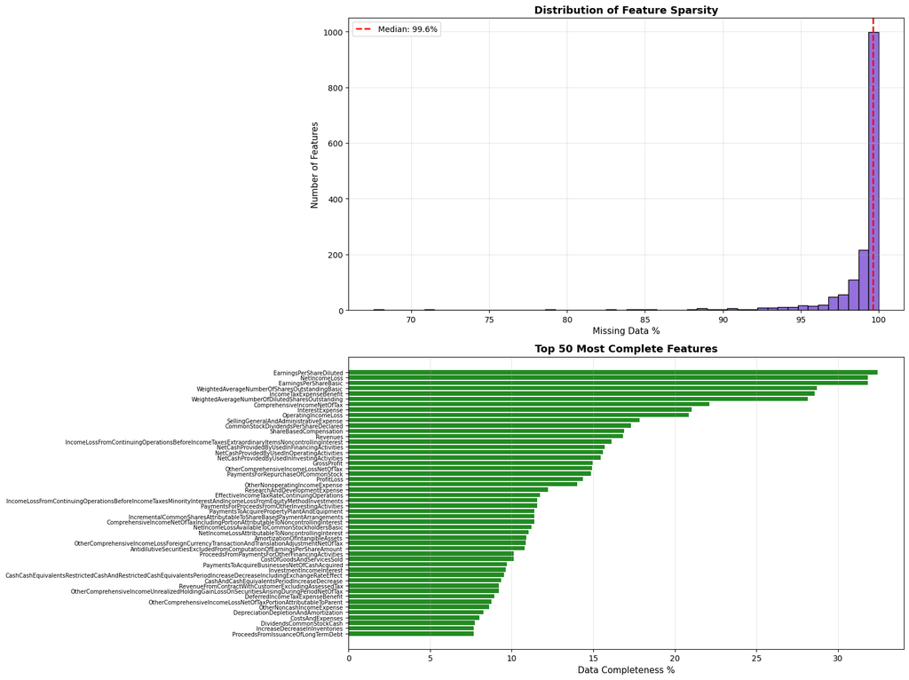

```python
import matplotlib.pyplot as plt

missing_pct = (metrics_wide[feature_columns].isna().sum() / len(metrics_wide) * 100).sort_values(ascending=True)

print(f"\nFeature Sparsity Statistics:")
print(f"  Average missing %: {missing_pct.mean():.2f}%")
print(f"  Median missing %: {missing_pct.median():.2f}%")
print(f"  Features with <10% missing: {(missing_pct < 10).sum()}")
print(f"  Features with <50% missing: {(missing_pct < 50).sum()}")
print(f"  Features with >90% missing: {(missing_pct > 90).sum()}")

# Visualize
fig, axes = plt.subplots(2, 1, figsize=(16, 12))

axes[0].hist(missing_pct.values, bins=50, color='mediumpurple', edgecolor='black')
axes[0].set_xlabel('Missing Data %', fontsize=11)
axes[0].set_ylabel('Number of Features', fontsize=11)
axes[0].set_title('Distribution of Feature Sparsity', fontsize=13, fontweight='bold')
axes[0].axvline(missing_pct.median(), color='red', linestyle='--', linewidth=2, label=f'Median: {missing_pct.median():.1f}%')
axes[0].legend()
axes[0].grid(True, alpha=0.3)

top_50_complete = missing_pct.head(50)
axes[1].barh(range(len(top_50_complete)), 100 - top_50_complete.values, color='forestgreen')
axes[1].set_yticks(range(len(top_50_complete)))
axes[1].set_yticklabels(top_50_complete.index, fontsize=7)
axes[1].set_xlabel('Data Completeness %', fontsize=11)
axes[1].set_title('Top 50 Most Complete Features', fontsize=13, fontweight='bold')
axes[1].invert_yaxis()
axes[1].grid(True, alpha=0.3, axis='x')

plt.tight_layout()
plt.show()
```

### **Step 16: Clean Features and Define Target**

We prepare features for modeling by:

1. Replacing infinite values with NaN
2. Capping extreme outliers at the 1st and 99th percentiles (winsorization)
3. Defining our feature matrix (X) and target variable (y = Market Cap)
4. Applying log transformation to Market Cap to handle exponential growth patterns

```python
import numpy as np
import warnings
warnings.filterwarnings("ignore")


for col in feature_columns:
    # Replace infinities with NaN
    metrics_wide[col] = metrics_wide[col].replace([np.inf, -np.inf], np.nan)

    # Cap extreme outliers at 1st and 99th percentile
    q99 = metrics_wide[col].quantile(0.99)
    q01 = metrics_wide[col].quantile(0.01)
    metrics_wide[col] = metrics_wide[col].clip(q01, q99)

print(f"Total NaN values in features: {metrics_wide[feature_columns].isna().sum().sum()}")

# Prepare final dataset
ml_data = metrics_wide.copy()
ml_data = ml_data.sort_values('best_filed_date').reset_index(drop=True)

# Define features (X) and target (y)
X = ml_data[feature_columns].copy()
y_market_cap_original = ml_data['Market_Cap'].copy()
shares = ml_data['Current_Shares_Outstanding'].copy()  # Changed: use Current_Shares_Outstanding
actual_prices = ml_data[avg_price_col].copy()
reference = ml_data[['Ticker', 'best_filed_date']].copy()

print(f"\nFinal dataset:")
print(f"  Features (X): {X.shape}")
print(f"  Target (Market Cap): {len(y_market_cap_original)}")
print(f"  Average Market Cap: ${y_market_cap_original.mean()/1e9:.2f}B")
print(f"  Average Price: ${actual_prices.mean():.2f}")

# Log transform (handles exponential growth better)
y_market_cap = np.log1p(y_market_cap_original)

print(f"Original Market Cap range: ${y_market_cap_original.min()/1e9:.2f}B to ${y_market_cap_original.max()/1e9:.2f}B")
print(f"Log-transformed range: {y_market_cap.min():.2f} to {y_market_cap.max():.2f}")
print(f"This allows model to learn exponential growth patterns")
```

```
Total NaN values in features: 2573647

Final dataset:
  Features (X): (1669, 1562)
  Target (Market Cap): 1669
  Average Market Cap: $225.37B
  Average Price: $112.95
Original Market Cap range: $2.26B to $4263.68B
Log-transformed range: 21.54 to 29.08
This allows model to learn exponential growth patterns
```

### **Step 17: Remove Perfectly Correlated Features**

Features with correlation > 0.99 to the target are likely spurious - they typically appear in only 1-2 samples and create the illusion of perfect predictive power. Removing these prevents overfitting to noise.

```python
# Calculate correlations with target on FULL dataset
correlations = X.corrwith(y_market_cap).abs()

# Remove features with perfect correlation (1.0) or very high correlation (>0.99)
# These are likely features that appear in only 1-2 samples
perfect_corr_features = correlations[correlations > 0.99].index.tolist()

print(f"Features with correlation > 0.99: {len(perfect_corr_features)}")
print(f"Removing these features to prevent overfitting...")

# Keep only features with correlation < 0.99
good_features = [f for f in feature_columns if f not in perfect_corr_features]

print(f"\nFeatures before: {len(feature_columns)}")
print(f"Features after: {len(good_features)}")

# Update X with only good features
X = X[good_features].copy()
feature_columns = good_features

print(f"✓ Removed {len(perfect_corr_features)} perfectly correlated features")
```

```
Features with correlation > 0.99: 138
Removing these features to prevent overfitting...

Features before: 1562
Features after: 1424
✓ Removed 138 perfectly correlated features
```

### **Step 18: Analyze Feature Correlations with Target**

We calculate and visualize the correlation between each financial metric and Market Cap. This reveals:

- **Top positive correlations:** Features that increase with market cap
- **Top negative correlations:** Features that decrease with market cap

These correlations help us understand which financial metrics are most related to company value.

```
Total features with valid correlations: 1035

Top 25 Positive Correlations with Market Cap:
 1. IncomeTaxExpenseBenefitContinuingOperations        +0.9870
 2. SegmentReportingInformationRevenueFromExternalCustomers +0.9817
 3. InterestExpenseBorrowings                          +0.9812
 4. RestructuringCosts                                 +0.9785
 5. PolicyholderBenefitsAndClaimsIncurredHealthCare    +0.9741
 6. SegmentReportingInformationIntersegmentRevenue     +0.9725
 7. IncomeTaxReconciliationForeignIncomeTaxRateDifferential +0.9689
 8. MaintenanceRevenue                                 +0.9672
 9. DisposalGroupIncludingDiscontinuedOperationOtherExpense +0.9664
10. GainLossOnSaleOfNotesReceivable                    +0.9656
11. DebtConversionConvertedInstrumentAmount1           +0.9620
12. DefinedContributionPlanEmployerDiscretionaryContributionAmount +0.9617
13. IncreaseDecreaseInSecuritiesLoanedTransactions     +0.9612
14. InvestmentProgramProportionalAmortizationMethodAppliedNonIncomeTaxRelatedActivityAndOtherReturn +0.9601
15. PaymentsToAcquireEquitySecuritiesFvNi              +0.9541
16. BusinessAcquisitionProFormaRevenue                 +0.9499
17. SegmentReportingInformationOperatingIncomeLoss     +0.9479
18. GrossTransactionVolume                             +0.9463
19. IncomeTaxReconciliationOtherAdjustments            +0.9463
20. AmortizationOfAcquiredIntangibleAssets             +0.9440
21. FinancingReceivableExcludingAccruedInterestAllowanceForCreditLossWriteoff +0.9411
22. ProceedsFromSaleOfInvestmentProjects               +0.9393
23. LiabilityForUnpaidClaimsAndClaimsAdjustmentExpenseIncurredClaims1 +0.9391
24. IncomeTaxReconciliationIncomeTaxExpenseBenefitAtFederalStatutoryIncomeTaxRate +0.9357
25. IncreaseDecreaseInSecuritiesBorrowed               +0.9351

Top 25 Negative Correlations with Market Cap:
 1. ProductWarrantyExpense                             -0.8509
 2. DefinedBenefitPlanNetPeriodicBenefitCost           -0.8581
 3. StockIssuedDuringPeriodValueOther                  -0.8647
 4. ProceedsFromDebtMaturingInMoreThanThreeMonths      -0.8693
 5. ProceedsFromSaleOfEquityMethodInvestments          -0.8718
 6. BusinessCombinationStepAcquisitionEquityInterestInAcquireeRemeasurementGainOrLoss -0.8719
 7. LossContingencyAccrualCarryingValueProvision       -0.8755
 8. FairValueOptionCreditRiskGainsLossesOnLiabilities  -0.8778
 9. ServicingAssetAtFairValueAdditions                 -0.8905
10. TranslationAdjustmentForNetInvestmentHedgeIncreaseDecreaseNetOfTax -0.8925
11. FairValueMeasurementWithUnobservableInputsReconciliationRecurringBasisAssetTransfersNet -0.9067
12. ContractuallySpecifiedServicingFeesAmount          -0.9102
13. LateFeeIncomeGeneratedByServicingFinancialAssetsAmount -0.9189
14. ProceedsFromEquityMethodInvestmentDividendsOrDistributionsReturnOfCapital -0.9192
15. NetCashProvidedByUsedInContinuingOperations        -0.9201
16. ChangeInUnrealizedGainLossOnFairValueHedgingInstruments -0.9224
17. OtherPreferredStockDividendsAndAdjustments         -0.9254
18. FairValueAssetsAndLiabilitiesMeasuredOnRecurringBasisGainLossIncludedInEarnings -0.9340
19. PreferredStockDividendsPerShareDeclared            -0.9625
20. IncreaseDecreaseInOutstandingChecksFinancingActivities -0.9694
21. OtherComprehensiveIncomeLossForeignCurrencyTransactionAndTranslationReclassificationAdjustmentRealizedUponSaleOrLiquidationNetOfTax -0.9713
22. InterestRevenueExpenseNet                          -0.9716
23. InvestmentIncomeNonoperating                       -0.9741
24. SegmentReportingReconcilingItemsRevenue            -0.9801
25. OtherThanTemporaryImpairmentLossesInvestmentsHeldtomaturitySecurities -0.9868
```

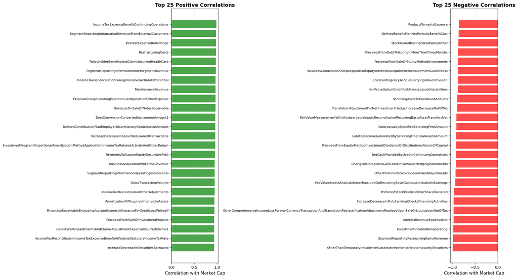

```python
# Calculate correlations between features and Market Cap
correlations = X.corrwith(y_market_cap).sort_values(ascending=False)
correlations = correlations.dropna()

print(f"\nTotal features with valid correlations: {len(correlations)}")
print(f"\nTop 25 Positive Correlations with Market Cap:")
top_25_positive = correlations.head(25)
for i, (feature, corr) in enumerate(top_25_positive.items(), 1):
    print(f"{i:2d}. {feature:50s} {corr:+.4f}")

print(f"\nTop 25 Negative Correlations with Market Cap:")
top_25_negative = correlations.tail(25)
for i, (feature, corr) in enumerate(top_25_negative.items(), 1):
    print(f"{i:2d}. {feature:50s} {corr:+.4f}")

# Visualize top correlations
fig, axes = plt.subplots(1, 2, figsize=(18, 10))

# Top 25 positive
axes[0].barh(range(25), top_25_positive.values, color='green', alpha=0.7)
axes[0].set_yticks(range(25))
axes[0].set_yticklabels(top_25_positive.index, fontsize=8)
axes[0].set_xlabel('Correlation with Market Cap', fontsize=11)
axes[0].set_title('Top 25 Positive Correlations', fontsize=13, fontweight='bold')
axes[0].invert_yaxis()
axes[0].grid(True, alpha=0.3, axis='x')
axes[0].axvline(0, color='black', linewidth=0.5)

# Top 25 negative
axes[1].barh(range(25), top_25_negative.values, color='red', alpha=0.7)
axes[1].set_yticks(range(25))
axes[1].set_yticklabels(top_25_negative.index, fontsize=8)
axes[1].set_xlabel('Correlation with Market Cap', fontsize=11)
axes[1].set_title('Top 25 Negative Correlations', fontsize=13, fontweight='bold')
axes[1].invert_yaxis()
axes[1].grid(True, alpha=0.3, axis='x')
axes[1].axvline(0, color='black', linewidth=0.5)

plt.tight_layout()
plt.show()
```

### **Step 19: Fetch Sector Information**

We retrieve the industry sector (e.g., Technology, Healthcare, Finance) for each company from Yahoo Finance. This allows us to analyze whether the relationship between financial metrics and stock price varies by sector.

```python
def get_sector(ticker):
    try:
        return yf.Ticker(ticker).info.get('sector', 'Unknown')
    except:
        return 'Unknown'

unique_tickers = ml_data['Ticker'].unique()
print(f"Fetching sectors for {len(unique_tickers)} tickers...")

sector_map = {}
for i, ticker in enumerate(unique_tickers, 1):
    sector_map[ticker] = get_sector(ticker)
    if i % 5 == 0:
        print(f"  Processed {i}/{len(unique_tickers)}...")

ml_data['Sector'] = ml_data['Ticker'].map(sector_map)

print(f"\nSectors found: {ml_data['Sector'].nunique()}")
print("Sector distribution:")
print(ml_data['Sector'].value_counts())
```

```
Fetching sectors for 44 tickers...
  Processed 5/44...
  Processed 10/44...
  Processed 15/44...
  Processed 20/44...
  Processed 25/44...
  Processed 30/44...
  Processed 35/44...
  Processed 40/44...

Sectors found: 1
Sector distribution:
Sector
Unknown    1669
Name: count, dtype: int64
```

### **Step 20: Time-Based Train/Test Split**

We split data chronologically (80% train, 20% test) rather than randomly. This is crucial for time-series data because:

- We cannot use future information to predict the past
- This simulates real-world conditions where we train on historical data and predict forward
- It prevents data leakage that would inflate performance metrics

```python
# 80/20 time-based split
split_idx = int(len(ml_data) * 0.8)

X_train = X.iloc[:split_idx].copy()
X_test = X.iloc[split_idx:].copy()

y_train = y_market_cap.iloc[:split_idx].copy()
y_test = y_market_cap.iloc[split_idx:].copy()

shares_train = shares.iloc[:split_idx].copy()
shares_test = shares.iloc[split_idx:].copy()

actual_prices_train = actual_prices.iloc[:split_idx].copy()
actual_prices_test = actual_prices.iloc[split_idx:].copy()

reference_train = reference.iloc[:split_idx].copy()
reference_test = reference.iloc[split_idx:].copy()

sector_train = ml_data['Sector'].iloc[:split_idx].copy()
sector_test = ml_data['Sector'].iloc[split_idx:].copy()

print(f"Training set: {len(X_train)} samples")
print(f"  Date range: {reference_train['best_filed_date'].min()} to {reference_train['best_filed_date'].max()}")

print(f"\nTest set: {len(X_test)} samples")
print(f"  Date range: {reference_test['best_filed_date'].min()} to {reference_test['best_filed_date'].max()}")
```

```
Training set: 1335 samples
  Date range: 2009-07-22 00:00:00 to 2023-02-21 00:00:00

Test set: 334 samples
  Date range: 2023-02-21 00:00:00 to 2025-09-10 00:00:00
```

### **Step 21: Model 1 - Aggregate XGBoost**

Our baseline model trains a single XGBoost regressor on all companies combined. This assumes the relationship between financial metrics and market cap is the same across all companies and sectors.

**Approach:** Predict log(Market Cap) then convert to price using shares outstanding

```python
from xgboost import XGBRegressor
from sklearn.model_selection import train_test_split
from sklearn.metrics import mean_squared_error, r2_score
from sklearn.preprocessing import LabelEncoder

RANDOM_STATE = 42

model_aggregate = XGBRegressor(
    n_estimators=200,
    max_depth=6,
    learning_rate=0.1,
    subsample=0.8,
    colsample_bytree=0.8,
    random_state=RANDOM_STATE,
    n_jobs=-1
)

print("Training aggregate model...")
model_aggregate.fit(X_train, y_train)

# Predict in log scale
y_pred_aggregate_test_log = model_aggregate.predict(X_test)

# Transform back from log to actual market cap
y_pred_aggregate_test = np.expm1(y_pred_aggregate_test_log)

# Convert to prices
pred_prices_aggregate_test = y_pred_aggregate_test / shares_test.values

agg_test_r2 = r2_score(actual_prices_test, pred_prices_aggregate_test)
agg_test_rmse = np.sqrt(mean_squared_error(actual_prices_test, pred_prices_aggregate_test))

print(f"✓ Model 1 Results:")
print(f"  Test R²: {agg_test_r2:.4f}")
print(f"  Test RMSE: ${agg_test_rmse:.2f}")

# DEBUG
print(f"\nDEBUG Model 1:")
print(f"  Log predictions: min={y_pred_aggregate_test_log.min():.2f}, max={y_pred_aggregate_test_log.max():.2f}")
print(f"  Market cap ($B): min=${y_pred_aggregate_test.min()/1e9:.2f}, max=${y_pred_aggregate_test.max()/1e9:.2f}")
print(f"  Prices: min=${pred_prices_aggregate_test.min():.2f}, max=${pred_prices_aggregate_test.max():.2f}")
```

```
Training aggregate model...
✓ Model 1 Results:
  Test R²: -1.9429
  Test RMSE: $338.88

DEBUG Model 1:
  Log predictions: min=23.24, max=31.04
  Market cap ($B): min=$12.39, max=$30326.85
  Prices: min=$0.77, max=$4080.37
```

### **Step 22: Model 2 - Aggregate + Sector Feature**

```python
from sklearn.preprocessing import LabelEncoder

le = LabelEncoder()
sector_encoded_train = le.fit_transform(sector_train)
sector_encoded_test = le.transform(sector_test)

X_train_with_sector = X_train.copy()
X_test_with_sector = X_test.copy()
X_train_with_sector['Sector_Encoded'] = sector_encoded_train
X_test_with_sector['Sector_Encoded'] = sector_encoded_test

model_sector = XGBRegressor(
    n_estimators=200,
    max_depth=6,
    learning_rate=0.1,
    subsample=0.8,
    colsample_bytree=0.8,
    random_state=RANDOM_STATE,
    n_jobs=-1
)

print("Training aggregate + sector model...")
model_sector.fit(X_train_with_sector, y_train)

# Predict in log scale
y_pred_sector_test_log = model_sector.predict(X_test_with_sector)

# Transform back from log to actual market cap
y_pred_sector_test = np.expm1(y_pred_sector_test_log)

# Convert to prices
pred_prices_sector_test = y_pred_sector_test / shares_test.values

sector_test_r2 = r2_score(actual_prices_test, pred_prices_sector_test)
sector_test_rmse = np.sqrt(mean_squared_error(actual_prices_test, pred_prices_sector_test))

print(f"✓ Model 2 Results:")
print(f"  Test R²: {sector_test_r2:.4f}")
print(f"  Test RMSE: ${sector_test_rmse:.2f}")

# DEBUG
print(f"\nDEBUG Model 2:")
print(f"  Log predictions: min={y_pred_sector_test_log.min():.2f}, max={y_pred_sector_test_log.max():.2f}")
print(f"  Market cap ($B): min=${y_pred_sector_test.min()/1e9:.2f}, max=${y_pred_sector_test.max()/1e9:.2f}")
print(f"  Prices: min=${pred_prices_sector_test.min():.2f}, max=${pred_prices_sector_test.max():.2f}")
```

```
Training aggregate + sector model...
✓ Model 2 Results:
  Test R²: -6.3430
  Test RMSE: $535.29

DEBUG Model 2:
  Log predictions: min=23.49, max=31.57
  Market cap ($B): min=$15.94, max=$51369.54
  Prices: min=$0.71, max=$6911.59
```

### **Step 23: Model 3 - Individual Ticker Models**

Instead of one model for all companies, we train a separate model for each company with sufficient data (20 or more samples). This allows each company to have its own unique relationship between financials and valuation.

**Fallback:** Companies without enough training data use the aggregate model.

```python
ticker_models = {}
unique_tickers_train = reference_train['Ticker'].unique()

MIN_ROWS_PER_TICKER = 20

print(f"Training individual models for tickers with ≥{MIN_ROWS_PER_TICKER} samples...")

for ticker in unique_tickers_train:
    ticker_mask_train = reference_train['Ticker'] == ticker
    ticker_X_train = X_train[ticker_mask_train]
    ticker_y_train = y_train[ticker_mask_train]

    if len(ticker_X_train) < MIN_ROWS_PER_TICKER:
        continue

    ticker_model = XGBRegressor(
        n_estimators=100,
        max_depth=4,
        learning_rate=0.1,
        random_state=RANDOM_STATE,
        n_jobs=-1
    )

    ticker_model.fit(ticker_X_train, ticker_y_train)
    ticker_models[ticker] = ticker_model
    print(f"  ✓ {ticker}: trained on {len(ticker_X_train)} samples")

print(f"\nTrained {len(ticker_models)} individual ticker models")

# Make predictions
pred_market_cap_individual_test = np.zeros(len(X_test))

for i in range(len(X_test)):
    ticker = reference_test.iloc[i]['Ticker']

    if ticker in ticker_models:
        # Predict in log scale
        pred_log = ticker_models[ticker].predict(X_test.iloc[i:i+1])[0]
    else:
        # Fall back to aggregate model
        pred_log = model_aggregate.predict(X_test.iloc[i:i+1])[0]

    # Transform from log to actual market cap
    pred_market_cap_individual_test[i] = np.expm1(pred_log)

# Convert to prices
pred_prices_individual_test = pred_market_cap_individual_test / shares_test.values

individual_test_r2 = r2_score(actual_prices_test, pred_prices_individual_test)
individual_test_rmse = np.sqrt(mean_squared_error(actual_prices_test, pred_prices_individual_test))

print(f"✓ Model 3 Results:")
print(f"  Test R²: {individual_test_r2:.4f}")
print(f"  Test RMSE: ${individual_test_rmse:.2f}")

# DEBUG
print(f"\nDEBUG Model 3:")
print(f"  Market cap ($B): min=${pred_market_cap_individual_test.min()/1e9:.2f}, max=${pred_market_cap_individual_test.max()/1e9:.2f}")
print(f"  Prices: min=${pred_prices_individual_test.min():.2f}, max=${pred_prices_individual_test.max():.2f}")
```

```
Training individual models for tickers with ≥20 samples...
  ✓ AAPL: trained on 33 samples
  ✓ MRK: trained on 39 samples
  ✓ AMZN: trained on 27 samples
  ✓ RTX: trained on 29 samples
  ✓ IBM: trained on 40 samples
  ✓ KO: trained on 39 samples
  ✓ V: trained on 36 samples
  ✓ MA: trained on 28 samples
  ✓ LLY: trained on 27 samples
  ✓ NFLX: trained on 31 samples
  ✓ TMO: trained on 24 samples
  ✓ GE: trained on 22 samples
  ✓ JNJ: trained on 28 samples
  ✓ GS: trained on 42 samples
  ✓ XOM: trained on 40 samples
  ✓ CVX: trained on 40 samples
  ✓ UNH: trained on 35 samples
  ✓ MCD: trained on 29 samples
  ✓ WFC: trained on 39 samples
  ✓ BAC: trained on 37 samples
  ✓ JPM: trained on 37 samples
  ✓ CAT: trained on 21 samples
  ✓ PM: trained on 34 samples
  ✓ NVDA: trained on 41 samples
  ✓ CRM: trained on 31 samples
  ✓ AMAT: trained on 27 samples
  ✓ AXP: trained on 21 samples
  ✓ HD: trained on 32 samples
  ✓ WMT: trained on 23 samples
  ✓ ORCL: trained on 51 samples
  ✓ PEP: trained on 40 samples
  ✓ CSCO: trained on 38 samples
  ✓ MU: trained on 26 samples
  ✓ PG: trained on 22 samples
  ✓ COST: trained on 23 samples
  ✓ AMD: trained on 21 samples
  ✓ TMUS: trained on 23 samples
  ✓ LRCX: trained on 45 samples
  ✓ TSLA: trained on 26 samples
  ✓ ABBV: trained on 21 samples

Trained 40 individual ticker models
✓ Model 3 Results:
  Test R²: -1.9240
  Test RMSE: $337.79

DEBUG Model 3:
  Market cap ($B): min=$8.91, max=$30326.85
  Prices: min=$0.37, max=$4080.37
```

### **Step 24: Model 4 - Ensemble**

We combine predictions from all three models using weighted averaging:

- 30% Aggregate model
- 30% Sector model
- 40% Individual ticker models

Ensemble methods often outperform individual models by balancing their strengths and weaknesses.

```python
w1, w2, w3 = 0.3, 0.3, 0.4

pred_prices_ensemble_test = (
    w1 * pred_prices_aggregate_test +
    w2 * pred_prices_sector_test +
    w3 * pred_prices_individual_test
)

ensemble_test_r2 = r2_score(actual_prices_test, pred_prices_ensemble_test)
ensemble_test_rmse = np.sqrt(mean_squared_error(actual_prices_test, pred_prices_ensemble_test))

print(f"✓ Model 4 Results:")
print(f"  Test R²: {ensemble_test_r2:.4f}")
print(f"  Test RMSE: ${ensemble_test_rmse:.2f}")
```

```
✓ Model 4 Results:
  Test R²: -2.7916
  Test RMSE: $384.65
```

### **Step 25: Model Performance Comparison**

We compare all four models using:

- **R squared:** How much variance the model explains (1.0 = perfect, negative = worse than mean baseline)
- **RMSE:** Average prediction error in dollars

**Key Finding:** All models show negative R squared, indicating the financial metrics alone are insufficient to predict stock prices accurately.

```python
comparison_df = pd.DataFrame({
    'Model': [
        'Model 1: Aggregate',
        'Model 2: Aggregate + Sector',
        'Model 3: Individual Tickers',
        'Model 4: Ensemble'
    ],
    'Test_R2': [agg_test_r2, sector_test_r2, individual_test_r2, ensemble_test_r2],
    'Test_RMSE': [agg_test_rmse, sector_test_rmse, individual_test_rmse, ensemble_test_rmse]
})

comparison_df = comparison_df.sort_values('Test_R2', ascending=False)

print("\nModel Performance Comparison:")
print(comparison_df.to_string(index=False))

best_model_name = comparison_df.iloc[0]['Model']
print(f"\nBest Model: {best_model_name}")
```

```
Model Performance Comparison:
                      Model   Test_R2  Test_RMSE
Model 3: Individual Tickers -1.924015 337.785635
         Model 1: Aggregate -1.942945 338.877271
          Model 4: Ensemble -2.791617 384.648134
Model 2: Aggregate + Sector -6.343040 535.290239

Best Model: Model 3: Individual Tickers
```

### **Step 26: Visualize Predictions by Company**

For each company in the test set, we plot:

- Actual market cap over time (blue)
- Predicted market cap (orange)
- Prediction error band (gray fill)

Individual ticker metrics (R squared, RMSE, MAPE) help identify which companies the model predicts well vs. poorly.

```
Creating plots for 44 tickers (4 per page)...
```

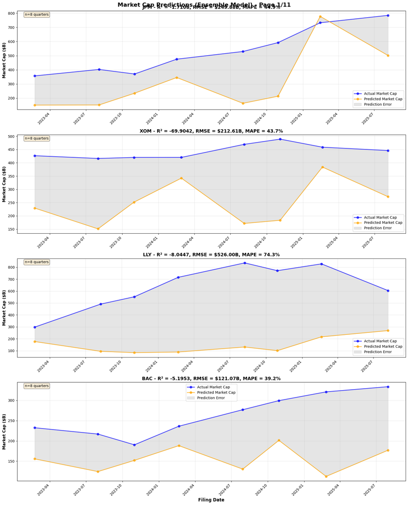

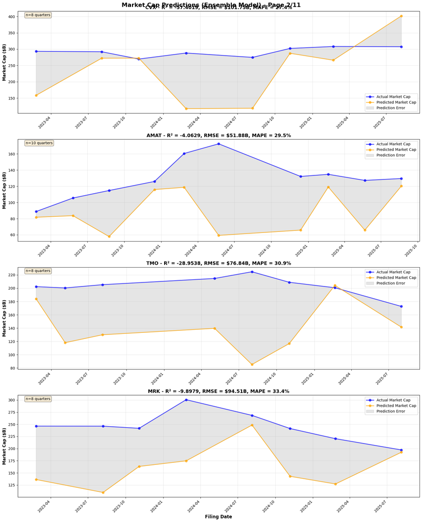

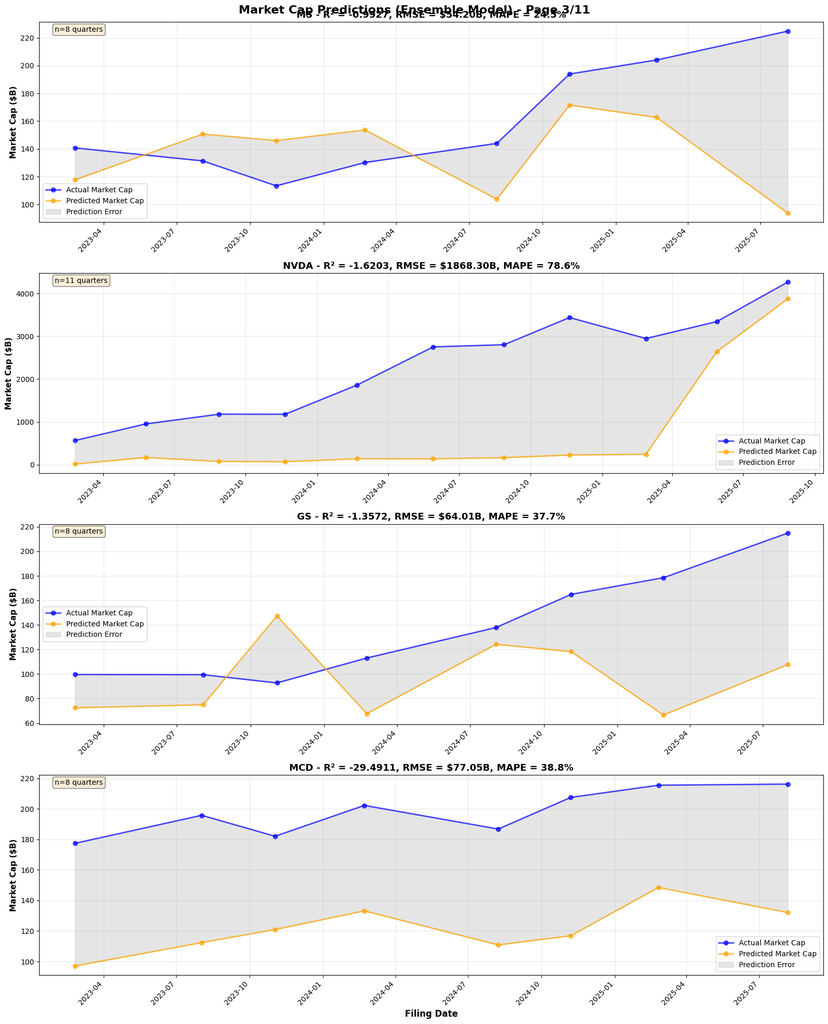

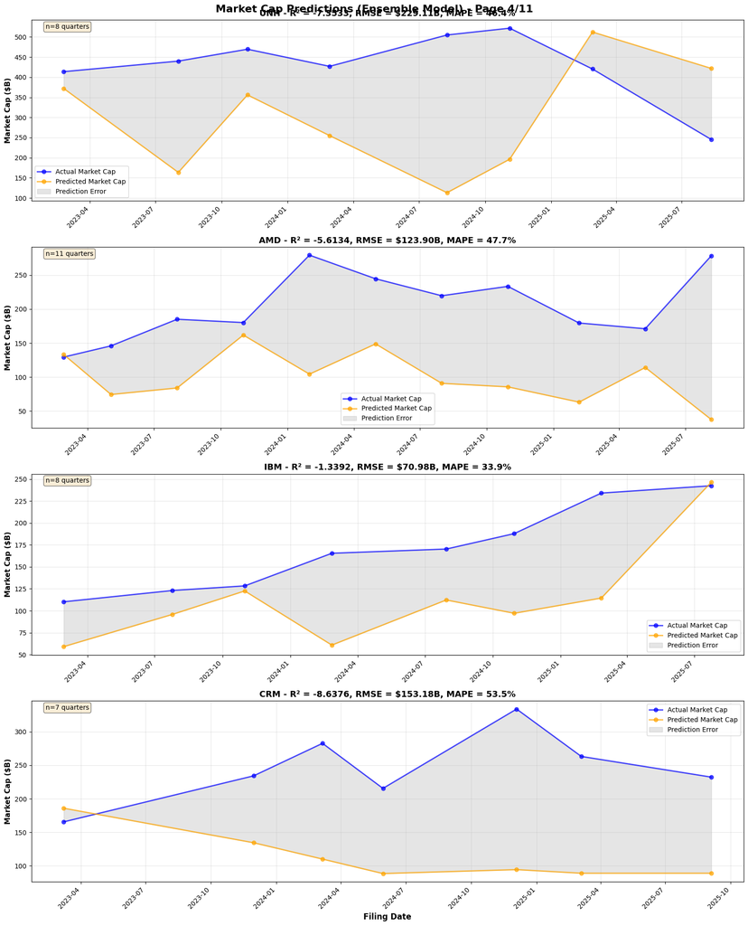

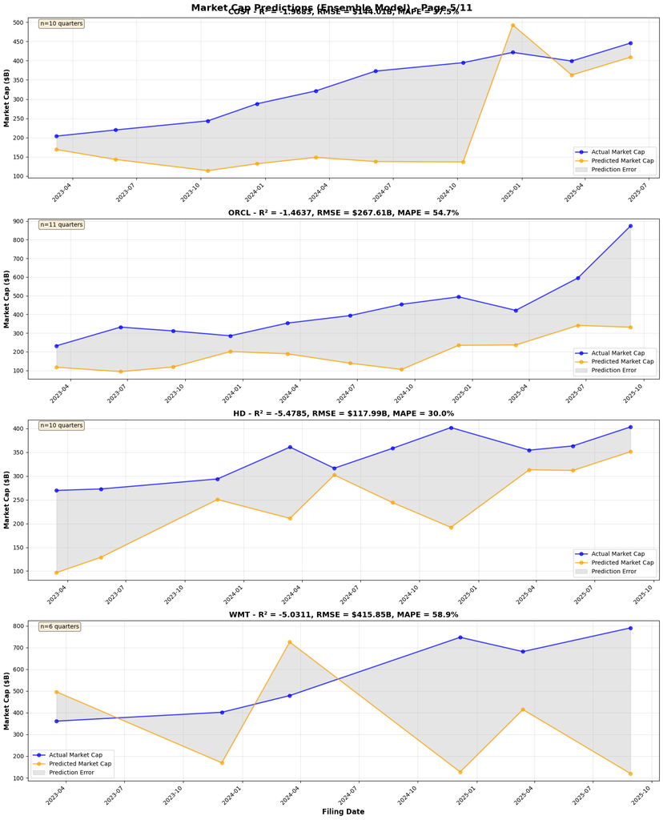

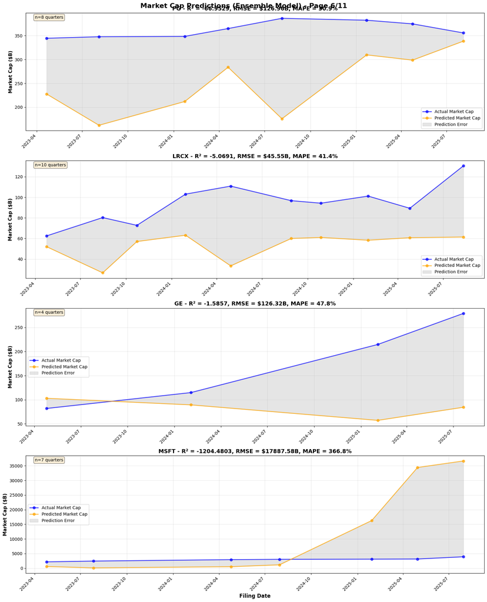

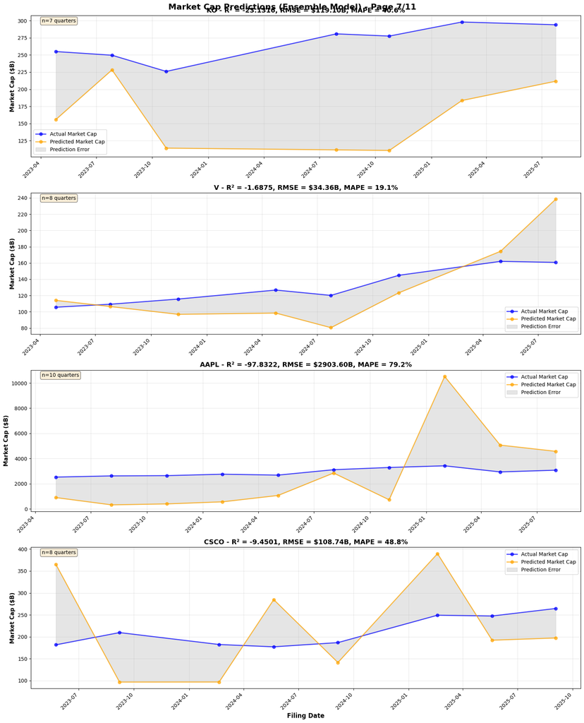

```python
# Get unique tickers in test set
unique_test_tickers = reference_test['Ticker'].unique()
n_tickers = len(unique_test_tickers)

print(f"Creating plots for {n_tickers} tickers (4 per page)...")

# Calculate predictions for ensemble — FIXED (no .values)
ensemble_pred_mc = np.asarray(pred_prices_ensemble_test) * np.asarray(shares_test)

# Group tickers into pages of 4
tickers_per_page = 4
n_pages = (n_tickers + tickers_per_page - 1) // tickers_per_page

for page in range(n_pages):
    start_idx = page * tickers_per_page
    end_idx = min(start_idx + tickers_per_page, n_tickers)
    page_tickers = unique_test_tickers[start_idx:end_idx]

    n_plots = len(page_tickers)

    fig, axes = plt.subplots(n_plots, 1, figsize=(16, 5*n_plots))
    if n_plots == 1:
        axes = [axes]

    fig.suptitle(
        f'Market Cap Predictions (Ensemble Model) - Page {page+1}/{n_pages}',
        fontsize=16, fontweight='bold'
    )

    for idx, ticker in enumerate(page_tickers):
        # Get data for this ticker
        ticker_mask = (reference_test['Ticker'] == ticker).values
        ticker_indices = np.where(ticker_mask)[0]

        ticker_dates = reference_test.iloc[ticker_indices]['best_filed_date'].values
        ticker_actual_mc = np.expm1(y_test.iloc[ticker_indices].values) / 1e9
        ticker_pred_mc = ensemble_pred_mc[ticker_indices] / 1e9

        # Sort by date
        sort_idx = np.argsort(ticker_dates)

        # Plot market cap
        ax = axes[idx]
        ax.plot(
            ticker_dates[sort_idx], ticker_actual_mc[sort_idx],
            'o-', label='Actual Market Cap',
            color='blue', alpha=0.7, markersize=6, linewidth=2
        )
        ax.plot(
            ticker_dates[sort_idx], ticker_pred_mc[sort_idx],
            'o-', label='Predicted Market Cap',
            color='orange', alpha=0.7, markersize=6, linewidth=2
        )

        # Error fill
        ax.fill_between(
            ticker_dates[sort_idx],
            ticker_actual_mc[sort_idx],
            ticker_pred_mc[sort_idx],
            alpha=0.2, color='gray', label='Prediction Error'
        )

        # Metrics
        ticker_r2 = r2_score(ticker_actual_mc, ticker_pred_mc)
        ticker_rmse = np.sqrt(mean_squared_error(ticker_actual_mc, ticker_pred_mc))
        ticker_mape = np.mean(
            np.abs((ticker_actual_mc - ticker_pred_mc) / ticker_actual_mc)
        ) * 100

        ax.set_ylabel('Market Cap ($B)', fontsize=11, fontweight='bold')
        ax.set_title(
            f'{ticker} - R² = {ticker_r2:.4f}, RMSE = ${ticker_rmse:.2f}B, '
            f'MAPE = {ticker_mape:.1f}%',
            fontsize=13, fontweight='bold'
        )
        ax.legend(loc='best', fontsize=10)
        ax.grid(True, alpha=0.3)
        plt.setp(ax.xaxis.get_majorticklabels(), rotation=45, ha='right')

        # Sample count
        ax.text(
            0.02, 0.98, f'n={len(ticker_dates)} quarters',
            transform=ax.transAxes,
            fontsize=10, verticalalignment='top',
            bbox=dict(boxstyle='round', facecolor='wheat', alpha=0.5)
        )

    axes[-1].set_xlabel('Filing Date', fontsize=12, fontweight='bold')
    plt.tight_layout()
    plt.show()


# --- Diagnostics Table ---
ticker_diagnostics = []

for ticker in unique_test_tickers:
    ticker_mask = (reference_test['Ticker'] == ticker).values
    ticker_indices = np.where(ticker_mask)[0]

    ticker_actual_mc = np.expm1(y_test.iloc[ticker_indices].values) / 1e9
    ticker_pred_mc = ensemble_pred_mc[ticker_indices] / 1e9

    ticker_diagnostics.append({
        'Ticker': ticker,
        'Samples': len(ticker_indices),
        'Actual_MC_Mean': ticker_actual_mc.mean(),
        'Actual_MC_Min': ticker_actual_mc.min(),
        'Actual_MC_Max': ticker_actual_mc.max(),
        'Pred_MC_Mean': ticker_pred_mc.mean(),
        'Pred_MC_Min': ticker_pred_mc.min(),
        'Pred_MC_Max': ticker_pred_mc.max(),
        'R2': r2_score(ticker_actual_mc, ticker_pred_mc),
        'RMSE': np.sqrt(mean_squared_error(ticker_actual_mc, ticker_pred_mc)),
        'MAPE_%': np.mean(np.abs((ticker_actual_mc - ticker_pred_mc) /
                                 ticker_actual_mc)) * 100
    })

print("\n✓ Ticker visualization complete")
```

[output not shown]

**Conclusion**

We CAN, however, find metrics that are positively correlated to stock prices. We know, for example, revenue is highly correlated because of the nature of the earnings effect of that variable (income/expense).

But because there are so many variables, utilizing simple models like linear regression dilutes the true correlative power of the features because they cannot account for the complex, non-linear interactions inherent in financial markets. This necessitates the use of more sophisticated, non-linear ensemble methods like XGBoost, which can better handle the high-dimensional, noisy nature of this data.

There probably IS some model or formula out there that predicts stock prices, we look at Jim Simons fund for example which uses quantitative finance to outperform the market consistantly over decades. To accomplish that, however, requires intense dedication to the ETL required and a profound understanding of the variables and trends that exist not only in the SEC documentation but in the macroeconomic and qualitative sources as well.

```python
%%shell
jupyter nbconvert --to html "/content/drive/MyDrive/Colab Notebooks/Johnson,Pham,Milestone 3 .ipynb"
```